# The Natural Proofs Barrier Against Data-Structure Lower Bounds

STCS, TIFR Mumbai | 2026-03-17

Tulasi Mohan Molli BITS Pilani, Hyderabad Campus

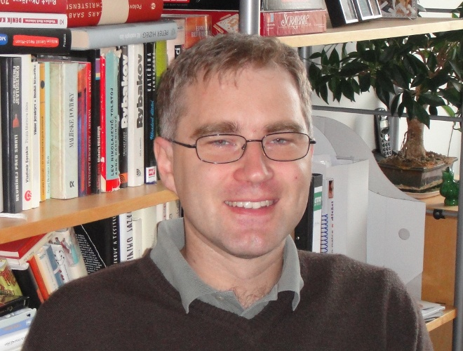

Michal Koucký

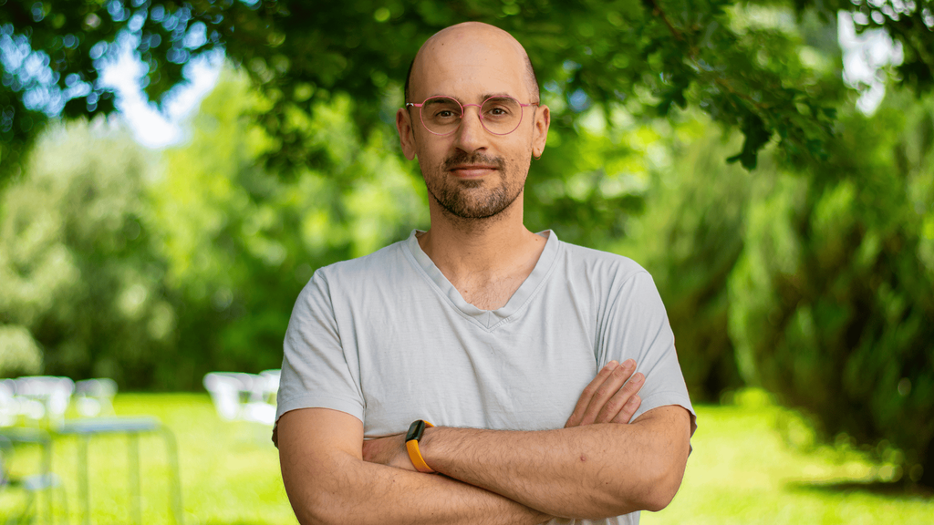

Bruno Loff

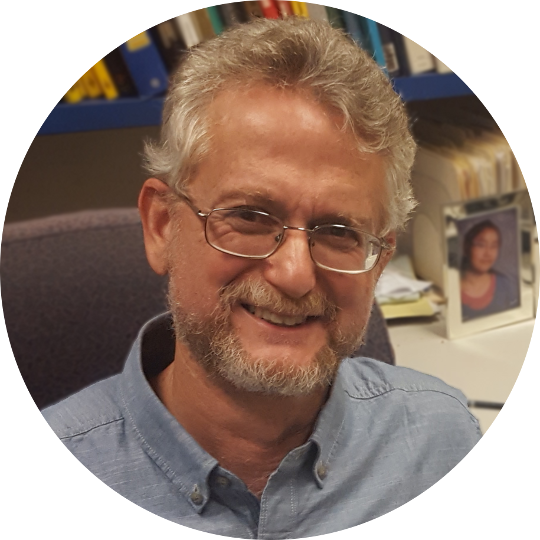

Michael Saks

# Staic Data Structures

- Staic Data Structures
- Static Lower Bounds; Survey
- Dynamic Data Structures
- Dynamic Lower Bounds; Survey
- Natural Proofs
- Porting Natural Proofs to Data Structures
- Open Questions

[interactive chart not shown]

## Static Data Structure Problems

[interactive chart not shown]

**Goal**

Preprocess and store the data, such that the queries can be answered fast (using few probes).

- M *vs* N ?

## Examples: Polynomial Evaluation

[interactive chart not shown]

**Polynomial Evaluation**

- **Data (D)**: $\mathbb{F}_p[x]^{< n}$.
- **Queries (Q)**: Points $a \in \mathbb{F}_p$.
- **Answer**: $P(a)$.

$Typically p = n^{1+ \Omega(1)}$.

- M = $p$
- N = $p^n$

## Examples: Range Counting

[interactive chart not shown]

**Range Counting**

- **Data (D)**: $S \subseteq [n]^2$, $|S| = n$.
- **Queries (Q)**: Axis-aligned rectangles $R$. $(a,b) \in [N] \times [N]$
- **Answer**: $|S \cap R|$.
- $N = \binom{n^2}{n}$
- $M = n^2$

## Examples: Vector-Matrix-Vector (VMV)

[interactive chart not shown]

**VMV Problem**

## The Cell Probe Model

**Cell Probe Model: $(S,w,t)$ solution**

- **Encoding** $\mathcal{E}: \mathcal{D} \to [w]^S$
- **Decision Trees**: $\{T_i\}$ one for each query $q_i$, with depth $t$.

[interactive chart not shown]

*Use Arrow Keys to Probing and Traversal*

## Parameter regimes

Lower bounds are typically studied in two different space regimes:

#### $M = (\log^c N)$

- $S = n \cdot \text{polylog}(n)$ bits.
- Near-linear space.
- Often related to Succinct Data Structures.
- Polynomial Evaluation

#### $\log M = (\log N)^c$

- $S = n^c$ for some $c > 1$.
- Polynomial space.
- Harder to prove significant lower bounds.
- Range Counting

## Extreme Upper Bounds

[interactive chart not shown]

**Store everything**

- $|S| = \frac{M \log |\mathcal{A}|}{w}$.
- $t_q = O(1)$.

**Store Nothing**

- $|S| = 0$.
- $t_q = O(\log N)$.

## Counting for lower bound benchmark

### Counting

1. # (S,w,t) solutions
2. # Static DS tablles of size $M \times N$

Comparing 1 and 2, $t_q \approx \Omega(\frac{\log M}{\log S})$.

- **Want:** LBs for Explicit Problem.
- current best Upper bounds: $O((\log M)^c)$
- current best Lower boudns: $\Omega(\log \log M)$
> - **Holy Grail**: Can we prove much stronger super logarithmic $\tilde\Omega(\log M)$Static Data Structure lower bounds?

# Static Lower Bounds; Survey

- Staic Data Structures
- Static Lower Bounds; Survey
- Dynamic Data Structures
- Dynamic Lower Bounds; Survey
- Natural Proofs
- Porting Natural Proofs to Data Structures
- Open Questions

## Existing Static Lower Bounds

| Paper | Technique | The Exact Formula ($t$) |
| --- | --- | --- |
| **[MNSW’98]** | Richness | $\Omega\left(\sqrt{\log\log M}\right)$ |
| **[BF’02, SV’08]** | Round Elimination | $\Omega\left(\frac{\log \log M}{\log \log \log M}\right)$ |
| **[PT’06]** | Round Elimination | $\Omega\left(\frac{\log M}{\log \frac{S \cdot w}{N}}\right)$ |
| **[Lar’12]** | Cell Sampling | $\Omega\left(\frac{\log M}{\log (S/N)}\right)$ |
| **[CKLM’18]** | Asymmetric Lifting | $\Omega\left(\frac{\log M}{\log (Sw/\log N)}\right)$ |
| **[KPI’25]** | CNF refutation | $S \ge \tilde{\Omega}\left( N^{\frac{2}{t}} (\log M)^{1-\frac{2}{t}} 2^{-w} \right)$ |

## Techniques for proving Static Lower Bounds

### Communication Complexity

- Asymmetric Communication Complexity
  - **Richness**: Discrepancy arguments.
  - **Round Elimination**: Predecessor.
- Four player communication complexity [Wseinstein, Yu]
- Lifting theorems for Composed functions
  - Simulation is better than richness

### Cell Sampling [Panigrahy et al. 2016]

### CNF Refutations [KPI’25]

## Cell Sampling: The Encoding

- Sample memory cells with prob. $p$. $L$
- Let $S(q)$ := cells probed by the query $q$ on data $d$.
- $\text{Prob}(S(q) \subseteq L) = p^t$.
- $E[|L|] = pS$
- Expected number of queries answered by $L$: $p^t \cdot |\mathcal{Q}|$

**Observation**: Each $d \in \mathcal{D}$ has $pS$ “Special” cells which can answer $p^t |Q|$ queries.

...

Memory \(S\)

...

Sampled \(L \subseteq [S]\)

- **Encoding**: Store the loccations and contents of these cells.

## Cell Sampling: Decoding

### Decoding Strategy

- Given $L$, simulate each query $q \in \mathcal{Q}$.
  - If $q$ probes outside $L \implies$ **Error**(erasure).
  - If $q$ probes inside $L \implies$ **Success**(recovery).
- **Property:** Any query column can be recovered by $p^t|Q|$ query answers.
- Polynmomial evaluation
- Does a random table have this property?
- **Property:** # columns which agree on particular $p^t|Q|$ query locations is small.

# Dynamic Data Structures

- Staic Data Structures
- Static Lower Bounds; Survey
- Dynamic Data Structures
- Dynamic Lower Bounds; Survey
- Natural Proofs
- Porting Natural Proofs to Data Structures
- Open Questions

## Dynamic Data Strucutre Problem

[interactive chart not shown]

**Frame**

Table with edge structure on the data points

- Typically the graph is Boolean hyper-cube.

## Example Dynamic Data Structure Problems

**Prefix Sum**

- **Data**: $\mathbb{F}_2^n$
- **Updates**: $A[i] \to A[i] + 1$
- **Queries**: $\sum_{j \leq i} A[j]$

**Connectivity**

- **Data**: Undirected Graphs
- **Updates**: Edges $\pm$
- **Queries**: $u \rightsquigarrow v$?

**Reachability**

- **Data**: Directed Graphs
- **Updates**: Edges $\pm$
- **Queries**: $u \to v$?

## The Cell Probe Model (Dynamic)

**(S, w, $t_u$, $t_q$) Solution**

- **Memory**: $S$ cells, $w$ bits per cell.
- **Updates**: Decision trees of depth $\le t_u$. modified.
- **$Queries$**: Decision trees of depth $\le t_q$

[interactive chart not shown]

# Dynamic Lower Bounds; Survey

- Staic Data Structures
- Static Lower Bounds; Survey
- Dynamic Data Structures
- Dynamic Lower Bounds; Survey
- Natural Proofs
- Porting Natural Proofs to Data Structures
- Open Questions

## Techniques for proving Dynamic lower bounds

- Non-adaptive , Memory-less [BL’16]
- Chronogram [FS’89]
- Information Transfer [PD’06]
- Chronogram + Cell Sampling [Lar’12]
- Chronogram + Weak Simulation [LWY’22] [LY’24]

## Dynamic Data Structure Lower Bounds

| Paper | Technique | The Exact Bound |
| --- | --- | --- |
| **[FS’89]** | Chronogram | $t = \Omega\left(\frac{\log M}{\log \log M}\right)$ |
| **[PD’06]** | Information Transfer | $t = \Omega(\log M)$ |
| **[Lar’12]** | Chronogram + Cell Sampling | $t = \Omega\left(\left(\frac{\log M}{\log \log M}\right)^2\right)$ |
| **[BL’16]** | Non-Adaptive, Memoreless; Encoding | $t_q = \Omega\left(\frac{M}{\log S}\right)$ |
| **[LWY’22]** | Chronogram + Weak Simulation | $t = \tilde{\Omega}(\log^{1.5} M)$ |
| **[LY’24]** | Chronogram + Weak Simulation | $t = \tilde{\Omega}(\log^{1.5} M)$ |

# Natural Proofs

- Staic Data Structures
- Static Lower Bounds; Survey
- Dynamic Data Structures
- Dynamic Lower Bounds; Survey
- Natural Proofs
- Porting Natural Proofs to Data Structures
- Open Questions

## The Razborov-Rudich Framework

### The Quest

- Goal: Separate $P$ from $NP$ via Circuit Complexity.
- Successes: Super-polynomial bounds for $AC^0, ACC^0$, Monotone Circuits.

### The Problem

- Almost all lower bound proofs followed a common pattern: **largeness**.
- This is the core of the **Natural Proofs** barrier.

*(Next: How Property $\mathcal{P}$ separates f*)*

[interactive chart not shown]

## Natural Property (Razborov-Rudich)

**Definition: Natural Property**

A property $\mathcal{P}$ of functions $f: \{0,1\}^n \to \{0,1\}$ is **Natural** if:

1. **Largeness**: $\mathcal{P}$ contains a large fraction ($1/2^{O(n)}$) of all functions.
2. **Constructivity**: $\mathcal{P}(f)$ is efficiently decidable.
3. **Usefulness**: $f \in \mathcal{P} \implies f \notin \text{CircuitClass}$.

**Theorem Informal[RR’94]**

A natural proof against $\mathcal{C}$ implies that $\mathcal{C}$ lacks strong PRFGs.

[interactive chart not shown]

## Indistinguihability and PRFGs

### The Indistinguishability Game

- Let $H_n$ be all functions,
- $\{F_k\}$ be the PRF family.

For **any** efficient Distinguisher $D$:
$$|\Pr_{k}[D(F_k) = 1] - \Pr_{f \in H_n}[D(f) = 1]| \le \epsilon$$

[interactive chart not shown]

## PRFs vs Natural Proofs

- A natural property gives a distinguisher between random functions and easy functions.
- PRFs are supported on the easy (structured) functions.
- The Distinguisher from the natural property successfully **breaks** the PRF.

[interactive chart not shown]

## Do PRFs exist?

- **PRGs exist if One-Way Functions exist!**
- Assumptions (Factoring, Discrete Log) $\implies$ **One-way functions**.
- **OWFs** $\implies$ **PRGs** [HILL ’99]
- **PRGs** $\implies$ **PRFs** [GGM ’86]
- We believe one-way functions exist; our entire modern financial and digital security infrastructure is built on this bedrock assumption.

# Porting Natural Proofs to Data Structures

- Staic Data Structures
- Static Lower Bounds; Survey
- Dynamic Data Structures
- Dynamic Lower Bounds; Survey
- Natural Proofs
- Porting Natural Proofs to Data Structures
- Open Questions

## Prior work; [KPI’25]

- Study Natural Proofs in the **Static setting**, specifically for the regime $M = (\log N)^c$.
- They use $NC^0$ PRGs to construct **Local PRGs**.
- **Limitations**:
  - Do not cover the **Dynamic** setting.
  - Miss other regimes of parameters.
  - Provide a sparse survey of lower bound techniques compared to this work.

## Local and LLU PRFs

**Local PRFs**

- a.k.a. **Pseudorandom Static** DS
- Queries are computable using short decision trees.
- The table looks random $(s,\epsilon)$-secure.

**LLU PRFs**

- a.k.a. **Pseudorandom Dynamic** DS
- Queries and updates are computable using short decision trees.
- The table looks random $(s,\epsilon)$-secure.
> - **Conjecture**: Both Local and LLU PRFs our constructions are secure for parameters just above the state-of-the-art lower bounds.

## PRF Candidates

- **What is good about our candidates?**
  - If a technique is Natural, it implicitly defines a Distinguisher.
  - Our PRFs fool all **Distinguishers** that arise from existing lower bound techniques (Cell Sampling, CC, etc.).
- **Local PRF candidate**: Work for wider range of parameters than [KPI]
- **LLU PRF candidate**: First of its kind.

# Open Questions

- Staic Data Structures
- Static Lower Bounds; Survey
- Dynamic Data Structures
- Dynamic Lower Bounds; Survey
- Natural Proofs
- Porting Natural Proofs to Data Structures
- Open Questions

## How to Improve Lower Bounds?

- **Option 1**: Come up with non-natural techniques like Lifting or KRW.
- **Option 2**: If it is natural, it better break our candidate PRGs.
  - **Approach**: Start by breaking our PRGs.
  - **Success**: The KPI lower bound itself came out of an attack on local PRGs!
- Can we come up with better Local and LLU PRGs?

### Thank You!

**Questions?**